# Analýza Časových Radov

Timur Kramár

2024-02-24

# Výber a popis časového radu

## Časový rad

Pre účely tohto semestra budeme používať dáta o množstve medzinárodných pasažierov leteckých spoločností. Dokumentácia k dátam je dostupná napríklad [tu](https://www.rdocumentation.org/packages/TSA/versions/1.3/topics/airpass).

```r
library (fpp2)
data(airpass)
```

## Slovná charakterizácia

Ide o časový rad s intervalom merania 1 mesiac, ktorý vyjadruje množstvo medzinárodných pasažierov v rokoch 1949 až 1961. Hodnoty začínajú na pomerne nízkych číslach, okolo 100, ku koncu dosahujú niekoľko stoviek s jasným rastúcim trendom. Dáta očividne obsahujú sezónnu zložku, ktorej veľkosť je závislá od trendu, preto ide pravdepodobne o multiplikatívnu dekompozíciu a budeme používať adaptívny prístup.

## Vykreslenie časového radu

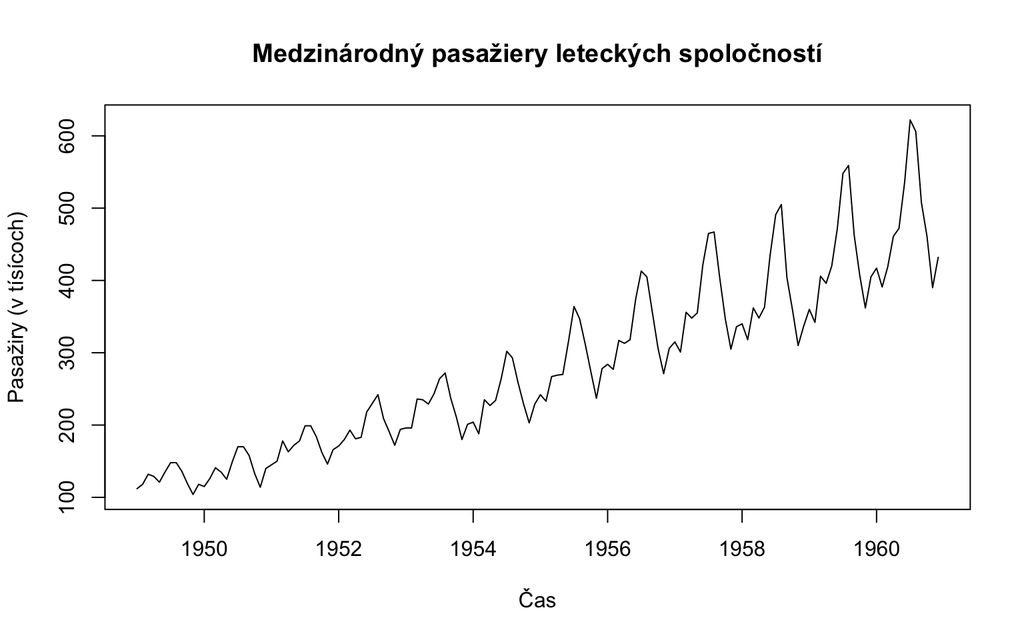

```r
plot(airpass,type = "l", main = "Medzinárodný pasažiery leteckých spoločností",
     xlab = "Čas", ylab = "Pasažiry (v tísícoch)")
```

## Základné údaje o časovom rade

```r
summary_statistics <- data.frame(
  Počet = length(airpass),
  Minimálna = min(airpass),
  Maximálna = max(airpass),
  Medián = median(airpass),
  Stredná_hodnota = mean(airpass),
  Smerodajná_odchýlka = sd(airpass)
)

kable(
  summary_statistics,
  caption = "Sumárne štatistiky pre airpass",
  booktabs = TRUE,
)
```

Sumárne štatistiky pre airpass

| Počet | Minimálna | Maximálna | Medián | Stredná_hodnota | Smerodajná_odchýlka |
| --- | --- | --- | --- | --- | --- |
| 144 | 104 | 622 | 265.5 | 280.2986 | 119.9663 |

## Rozdelenie na trénovaciu a vyhodnocovaciu zložku

Rozdelme dáta na trénovaciu (prvých 9 rokov) a vyhodnocovaciu (posledné 3 roky) zložku. Použijeme balík `tsibble` z `tydivertz` na ľahšiu manipuláciu.

```r
# Instalácia a načítanie potrebných balíkov
library(tsibble)
library(dplyr)
library(ggplot2)
```

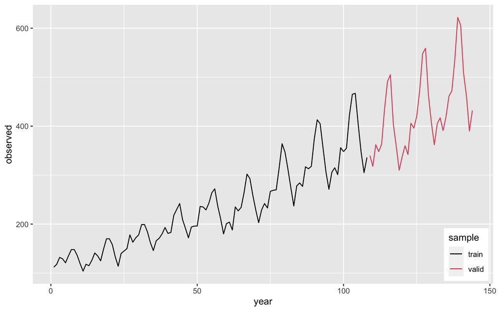

```r
dat <- fit <- list()
# Konverzia na tsibble
dat$full$observed <- ts(airpass)

# Rozdelenie urobíme po 9 rokoch
ratio <- 0.75

dat$train <- data.frame(observed = head(dat$full$observed, ratio*length(dat$full$observed)))
dat$valid <- data.frame(observed = tail(dat$full$observed, (1-ratio)*length(dat$full$observed)))

nT <- nrow(dat$train)
nV <- nrow(dat$valid)

# Vykreslenie grafu
list(train = dat$train$observed,
     valid = dat$valid$observed) |>
  with({
    ggplot() + autolayer(train) + autolayer(valid) +
      scale_color_manual(values = c(train = 1, valid = 2)) +
      guides(color = guide_legend(title = "sample")) +
      theme(legend.position = c(0.99, 0.01),
            legend.justification = c("right","bottom")) +
      labs(x = "year", y = "observed")
  })
```

# Dekompozícia časového radu

## Stabilizácia

Vidíme že časový rad obsahuje veľmi jasný stúpajúci trend, ktorý sa bude dať modelovať lineárnym modelom, alebo prípadne exponenciálnym. Zároveň je úplne evidentná sezónna zložka, ktorá bude mať periódu pravdepodobne 1 rok, čiže 12 meraní. Zároveň vidíme, že amplitúda rozptylu je závislá od trendu.

Predpokladajme teda na chvíľu, že ide o exponenciálny trend, potom môžeme časový rad logaritmovať, čím dosiahneme stacionaritu a neskôr môžme skúmať trend ako lineárny.

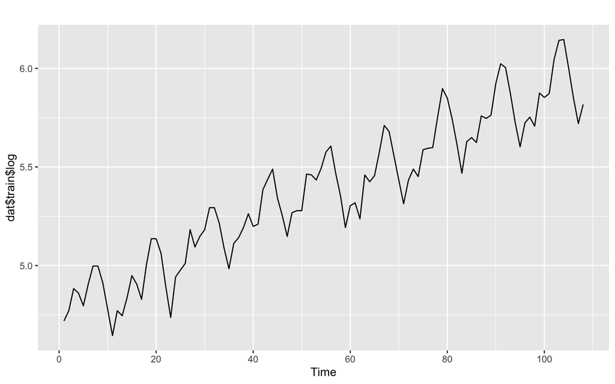

```r
# Logaritmová transformácia
dat$train$log <- log(dat$train$observed)

# Plotting
autoplot(dat$train$log)
```

Vidíme, že toto účel splnilo, nakoľko máme jasný stacionárny rad s lineárnym trendom. Ďalej budeme teda analyzovať aj tento časový rad.

## Odhadnutie trendu

Odhadnime trend logaritmizovaného časového radu a vypočítajme jeho štatistickú významnosť.

```r
fit$Tlin <- with(data = dat$train,
                 forecast::tslm(log ~ trend)
                 )
fit$Tlin |> summary() |> coef() |> round(4)
```

```
##             Estimate Std. Error  t value Pr(>|t|)
## (Intercept)   4.7712     0.0250 190.8852        0
## trend         0.0111     0.0004  27.8210        0
```

Vidíme že Pr hodnota je 0, teda nájdený trend je štatisticky významný. Vykreslime si ho:

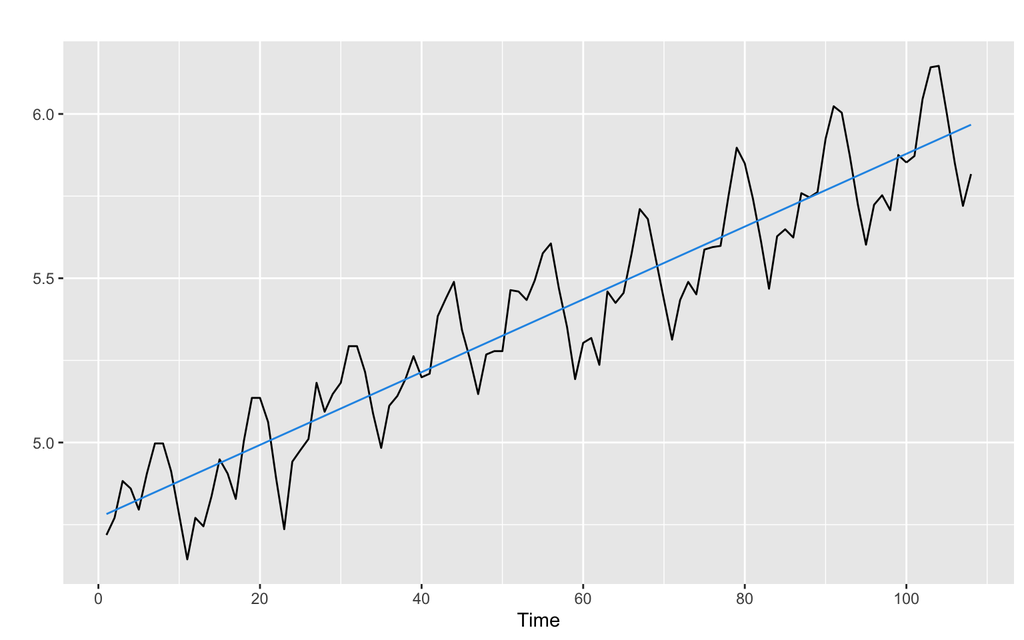

```r
dat$train$Tlin <- fitted(fit$Tlin)

with(dat$train,
     forecast::autoplot(log) +
       forecast::autolayer(Tlin, color = 4, show.legend = FALSE) +
       ylab("")
)
```

Nájdený trend popisuje vývoj tak dobre, že nemá zmysel skúšať hľadať nejaký iný model. Poďme sa teda pozrieť na sezónnu zložku.

## Sezónna zložka

Vykreslime si rezíduá po odpočítaní nájdeného trendu a príslušný korelogram

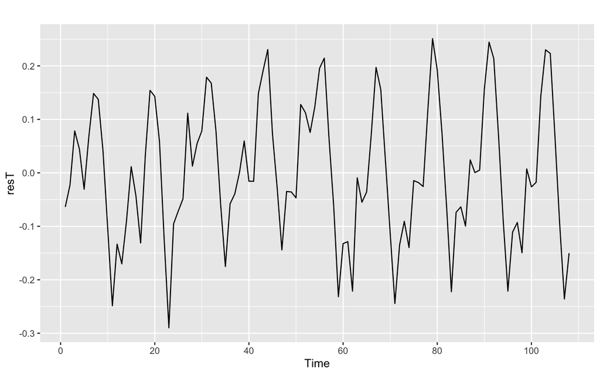

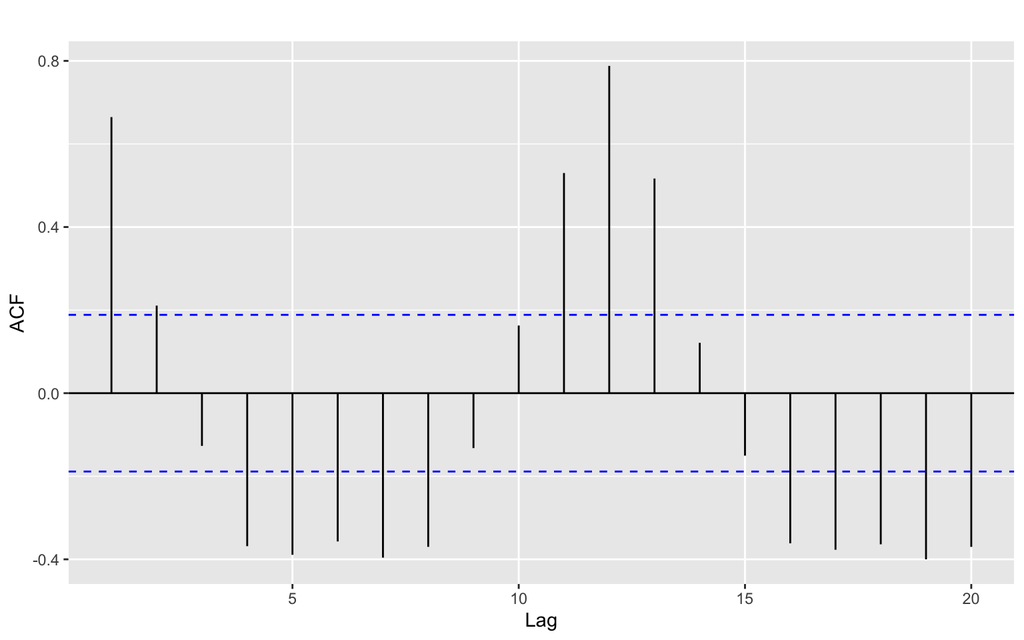

```r
dat$train$resT <- dat$train$log - dat$train$Tlin
with(dat$train, {
  forecast::autoplot(resT) |> print();
  forecast::Acf(resT, plot = FALSE) |>
    forecast::autoplot(show.legend = FALSE) + ggtitle("")
})
```

Na korelograme je jasne vidieť sezónnu zložku s periódou 12, čo zodpovedá práve faktu, že merania boli robené raz mesačne.

### Indikačné funkcie

Skúsme teda nájsť príslušnú sezónnu zložku pomocou indikačných funkcií.

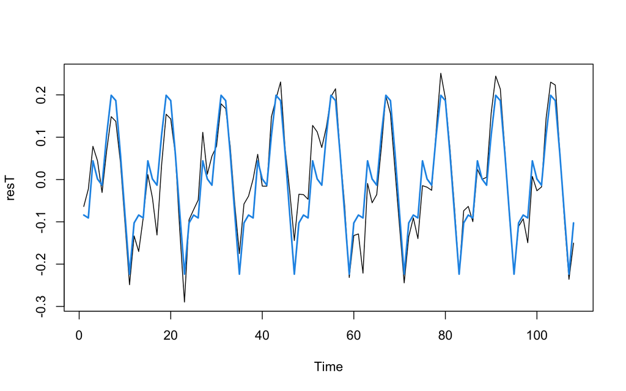

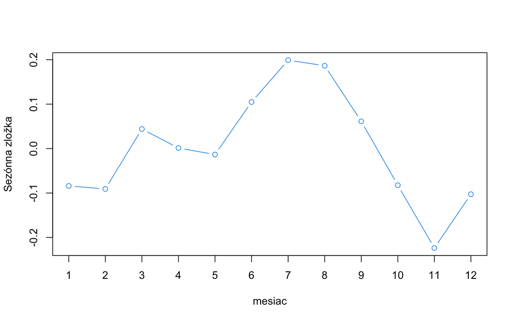

```r
#Pridáme premennú indikujúcu mesiac
dat$train$M <- factor(rep(1:12, length.out = length(dat$train$observed)))

fit$SInd <- lm(resT ~ M, dat$train)

dat$train$SInd <- fit$SInd |> fitted() |>
  ts() |> `tsp<-`(tsp(dat$train$HDP))
with(dat$train, {
  plot(resT)
  lines(SInd, col = 12, lwd = 2)
  plot(1:12, SInd[1:12], xaxt="n", xlab="mesiac", ylab = "Sezónna zložka", type = "b", col = 4)
  axis(1, at = 1:12, labels = 1:12)
})
```

Na prvom grafe vidíme modrou náš sezónny model a čiernou reziduá po odpočítaní trendu. Vidíme, pomerne vysokú mieru prekrytia. Druhý graf zobrazuje hodnoty pri indikačných funkciách. Nakoľko nejde zrovna o peknú sinusoidu, takéto riešenie sa javí vhodnejšie ako použitie goniometrických funkcií.

Vykreslime si trend spolu so sezónnou zložkou v porovnaní s nameranými dátami.

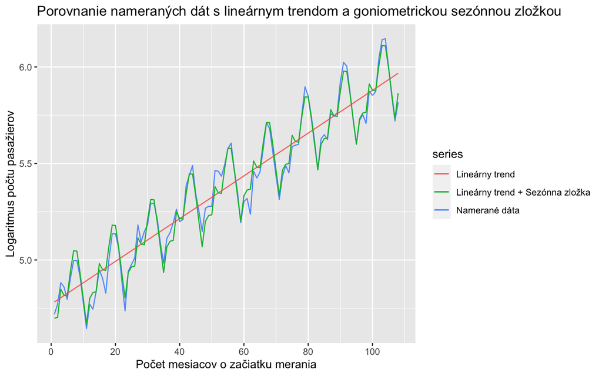

```r
autoplot(dat$train$log, series="Namerané dáta") +
  autolayer(dat$train$Tlin, series = "Lineárny trend") +
  autolayer(dat$train$Tlin + dat$train$SInd, series = "Lineárny trend + Sezónna zložka") +
  labs(
    title="Porovnanie nameraných dát s lineárnym trendom a goniometrickou sezónnou zložkou",
    y = "Logaritmus počtu pasažierov",
    x = "Počet mesiacov o začiatku merania")
```

A keď sa pozrieme iba na jednu periódu v strede meraní:

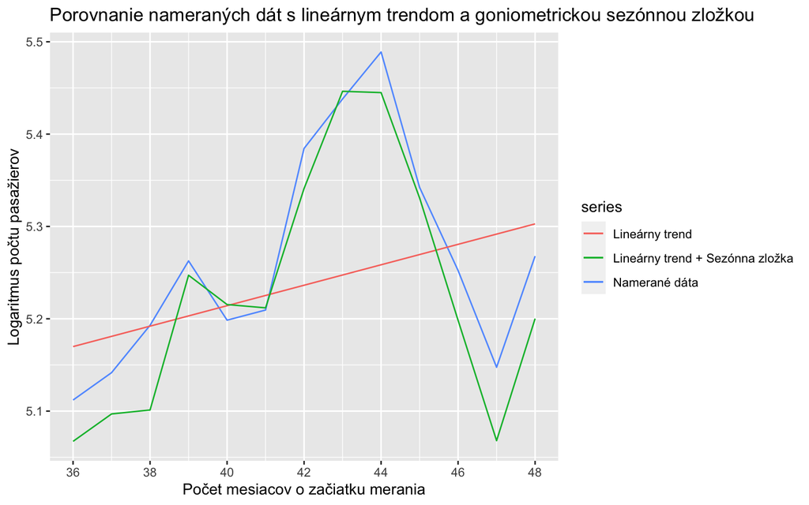

```r
autoplot(window(dat$train$log, start=36, end=48), series="Namerané dáta") +
  autolayer(window(dat$train$Tlin, start=36, end=48), series = "Lineárny trend") +
  autolayer(window(dat$train$Tlin, start=36, end=48) + window(dat$train$SInd, start=36, end=48), series = "Lineárny trend + Sezónna zložka") +
  labs(
    title="Porovnanie nameraných dát s lineárnym trendom a goniometrickou sezónnou zložkou",
    y = "Logaritmus počtu pasažierov",
    x = "Počet mesiacov o začiatku merania")
```

Pozrime sa ešte na reziduá po odpočítaní sezónnej zložky:

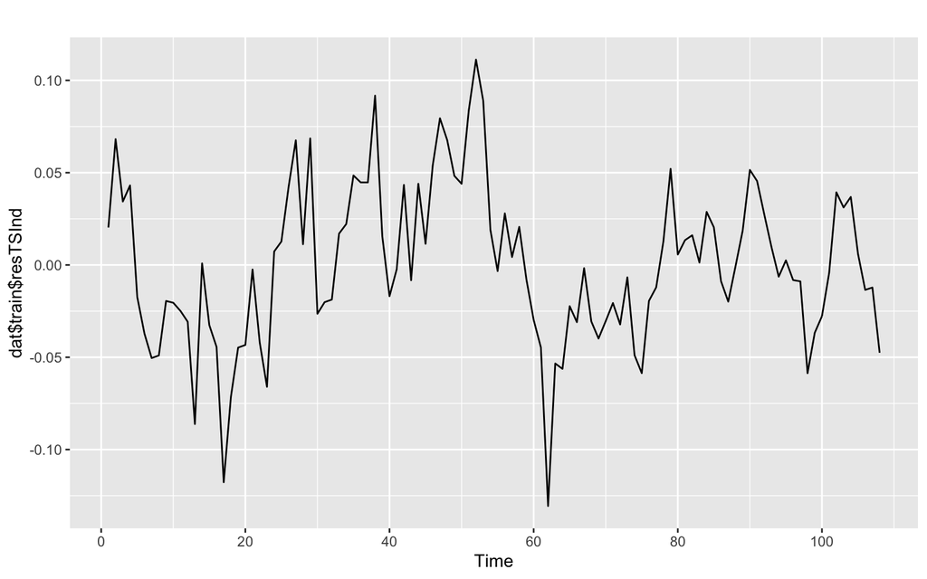

```r
dat$train$resTSInd <- ts(dat$train$resT - dat$train$SInd)

# zobrazenie
autoplot(dat$train$resTSInd)
```

Nedá sa povedať, že by tieto reziduá vyzerali ako biely šum, skúsme teda použiť goniometrické funkcie.

### Goniometrické funkcie

```r
dat$train$index <- seq(1, length(dat$train$observed))
fit$SGon <- lm(resT ~ cos(2*pi*index/12) + sin(2*pi*index/12), dat$train)
tmp <- fit$SGon |> coef() |> print()
```

```
##            (Intercept) cos(2 * pi * index/12) sin(2 * pi * index/12)
##          -4.143992e-18          -1.358360e-01          -3.689398e-02
```

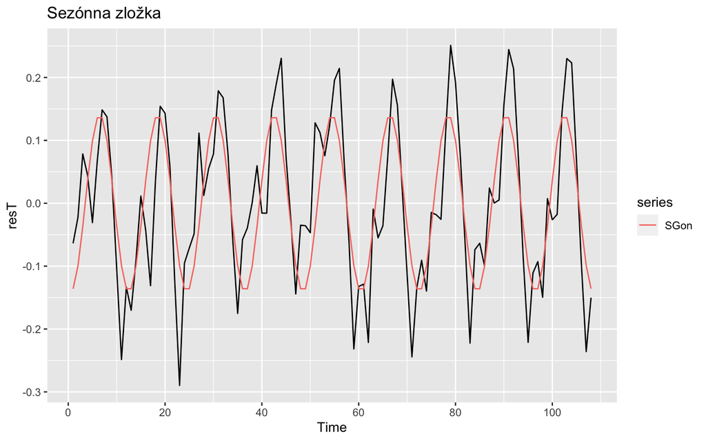

```r
dat$train$SGon <- ts(fit$SGon$fitted.values)
dat$train$resTSGon <- ts(fit$SGon$residuals)

with(dat$train,{
autoplot(resT, main = "Sezónna zložka") +
  autolayer(SGon)
})
```

Pri použití iba dvoch goniometrických funkcií na zachytenie sezónnej zložky s periódou 12 mesiacov výsledky nie sú až také presné ako pri použití indikačných funkcií. Reziduá v sebe očividne zahŕňajú ďalšie nezachytené sezónne zložky:

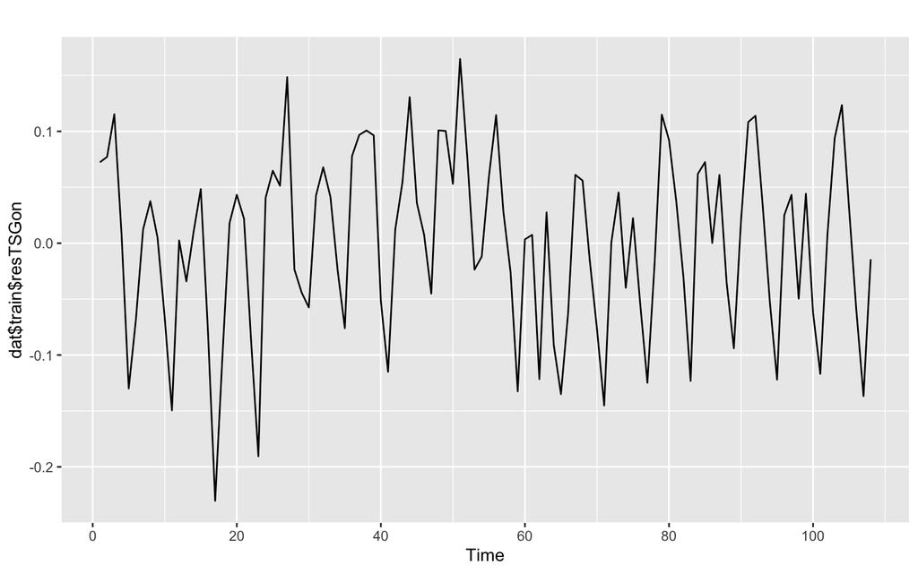

```r
autoplot(dat$train$resTSGon)
```

Mohli by sme spraviť sezónny model s viac parametrami, s rôznymi periódami ale keďže nie je úplne jasné, s akou periódou by sme mali sezónnu zložku hľadať, vystačíme si aj s týmto modelom. Pozrime sa ešte na porovnanie s nameranými dátami:

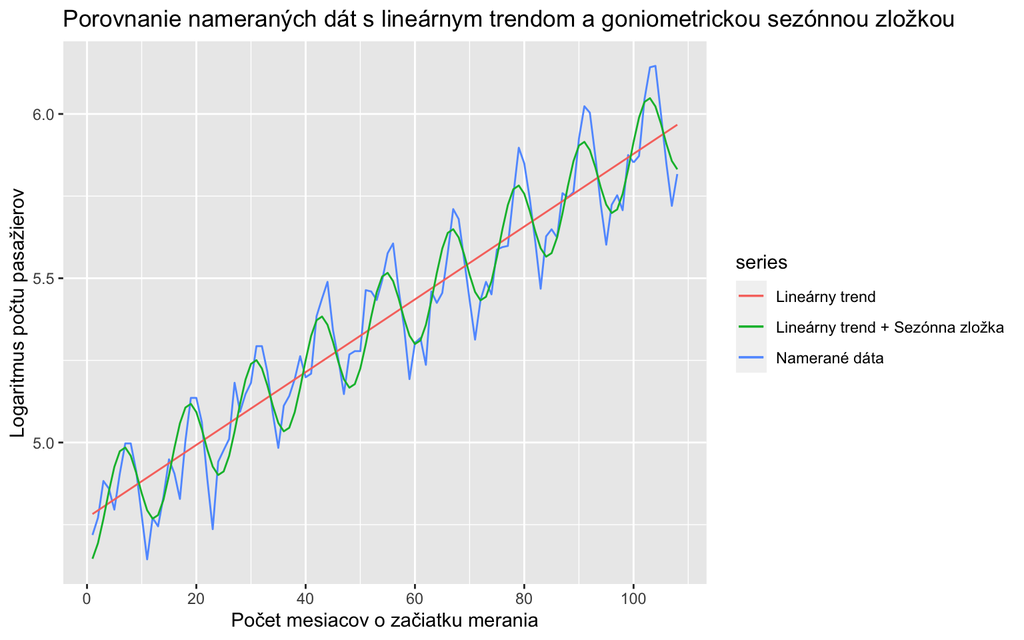

```r
autoplot(dat$train$log, series="Namerané dáta") +
  autolayer(dat$train$Tlin, series = "Lineárny trend") +
  autolayer(dat$train$Tlin + dat$train$SGon, series = "Lineárny trend + Sezónna zložka") +
  labs(title="Porovnanie nameraných dát s lineárnym trendom a goniometrickou sezónnou zložkou",
    y = "Logaritmus počtu pasažierov",
       x = "Počet mesiacov o začiatku merania")
```

A pri priblížení na jednu periódu:

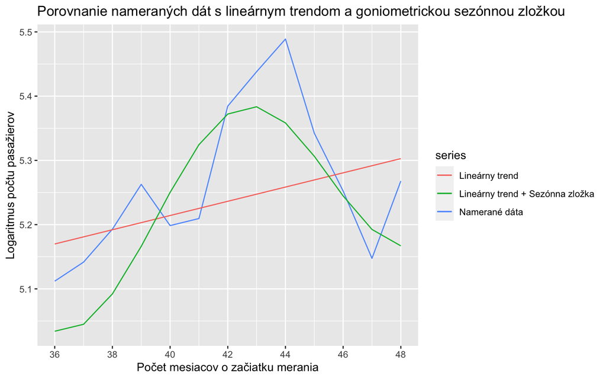

```r
autoplot(window(dat$train$log, start=36, end=48), series="Namerané dáta") +
  autolayer(window(dat$train$Tlin, start=36, end=48), series = "Lineárny trend") +
  autolayer(window(dat$train$Tlin + dat$train$SGon, start=36, end=48), series = "Lineárny trend + Sezónna zložka") +
  labs(title="Porovnanie nameraných dát s lineárnym trendom a goniometrickou sezónnou zložkou",
    y = "Logaritmus počtu pasažierov",
       x = "Počet mesiacov o začiatku merania")
```